# Examining the Canned Tuna Competitive Landscape

Mark Preston

December 9, 2018

### Using price elasticity models to assess tuna brand sales competition

For this analysis, I’ll be using canned tuna sales data from the Kilts Center for Marketing at the University of Chicago’s Booth School of Business to assess the competitive landscape for the product category. The data is extracted from the Dominick’s Finer Foods database and covers tuna sales as well as a measure of display activity, log price, and log wholesale price aggregated weekly for the chain.

I’m going to be focusing on product sales and brand log prices to develop individual price elasticity models. To ensure the analysis also includes multivariate models, I’ll develop logarithmic pricing models with each brand’s sales as the outcome variable with all every price included. Additionally, I’m interested in how brand pricing affects the total category volume so I’ll include a similar modelling approach by incorporating brand prices but, the outcome variable will be total sales. With both of these approaches, the idea is to better capture the interactive market dynamic.

I’m selecting this approach because these price elasticity models have fairly straightforward interpretations, which is essential for presentation to a business audience. A product group would be able to review the idea of changing sales and price levels in comparison to other brands. Additionally, since I’m using both individual and multivariate regression models, a range of constant and cross elasticities can be reviewed which would allow a group to understand their brand and the wider competitive landscape in concert.

```r
library(bayesm)
library(tidyverse)
library(corrplot)
library(gridExtra)
library(car)
library(kableExtra)
library(knitr)

theme_set(
  theme_minimal()
)

custom_kable <- function(x){
  kable(x, format = "html") %>%
    kable_styling(bootstrap_options = "striped")
}

data("tuna")
```

With this goal in mind, I’ve started by paring down the initial data set. For this, I’ve included all the brand movement and price variables. I’ve also added a new column for total sales, which will be the outcome variable for a portion of the analysis. To ensure each variable can be clearly interpreted, I’ve also added brand names to each column so each can be tracked better.

```r
brand_names <- c("starkist", "cs", "bb_solid", "bb_chunk",
                 "geisha", "bb_large", "hh_chunk")

tuna_brands <- tuna %>%
  rename_all(tolower) %>%
  rename_at(vars(2:29), function(x) paste0(x, "_", brand_names)) %>%
  rename_all(function(x) str_replace(string = x,
                                     pattern = "[0-9]",
                                     replacement = "")) %>%
  mutate(total_sales = move_starkist + move_cs + move_bb_solid + move_bb_chunk +
           move_geisha + move_bb_large + move_hh_chunk) %>%
  select(week, move_starkist, move_cs, move_bb_solid, move_bb_chunk,
         move_geisha, move_bb_large, move_hh_chunk, total_sales, lprice_starkist,
         lprice_cs, lprice_bb_solid, lprice_bb_chunk, lprice_geisha,
         lprice_bb_large, lprice_hh_chunk)
```

### Brand exploratory analysis: Volume, share, and price focus

The data inherently involves time so I wanted to check on how many entries exist in the series. As seen, there are 338 rows, which amounts to just over size years of tuna brand category data. Following the initial variable review, there are 16 columns remaining with a sales volume and price focus.

```r
data.frame(
  dimension = c("rows", "columns"),
  value = c(dim(tuna_brands)[1], dim(tuna_brands)[2])
) %>% custom_kable()
```

| dimension | value |
| --- | --- |
| rows | 338 |
| columns | 16 |

Starting the analysis, I’ve included a sales volume quantile table for each brand. The values here represent the unit sales per brand, which in this case means a single can of tuna. From this, it appears that Chicken of the Sea (cs) has the highest single week of sales with 579,037 units sold. In comparison, this is well over 100,000 units more than the second largest week (442,490), which was registered by Starkist. However, Starkist has larger quantiles compared to Chicken of the Sea, which makes me think it likely has the largest market share. The other large volume players appear to be Bumble Bee chunk and HH chunk, which both have top weeks over 100,000 units.

On the lower volume side, Bumble Bee large can has the narrowest volume quantile range with a top week of only 2032 units. That said, it seems to be a slightly different product, owing to the large serving size, so this might help explain some of the difference. Beyond that, Geisha and Bumble Bee solid seem to be lower volume brands as well. Bumble Bee is the only firm with numerous brands represented as well. These are the first volume insights of the analysis, which appear to suggest there might be two broad tiers in the category for high volume and lower specialty brands.

```r
tuna_brands %>%
  select(2:8) %>%
  apply(., 2, quantile) %>%
  as.data.frame() %>%
  rownames_to_column(var = "quantile") %>%
  custom_kable()
```

| quantile | move_starkist | move_cs | move_bb_solid | move_bb_chunk | move_geisha | move_bb_large | move_hh_chunk |
| --- | --- | --- | --- | --- | --- | --- | --- |
| 0% | 4428.00 | 2525.0 | 8.00 | 1857.00 | 859.00 | 21.0 | 739.00 |
| 25% | 8038.75 | 4627.5 | 2061.00 | 4343.75 | 2158.00 | 824.5 | 4277.25 |
| 50% | 10801.00 | 6633.0 | 2537.50 | 6215.50 | 2617.50 | 1044.5 | 6315.00 |
| 75% | 20325.50 | 11176.0 | 3042.75 | 11235.25 | 3411.75 | 1309.0 | 9044.25 |
| 100% | 442490.00 | 579037.0 | 9287.00 | 268543.00 | 9277.00 | 2032.0 | 148541.00 |

Continuing the volume focus, I’ve developed a histogram for each brand. The plot reveals that the previous upper quantiles I described were the volume exceptions. Six of the brands have positively skewed volume distributions. In fact, Starkist, Chicken of the Sea, Bumble Bee Chunk, and HH Chunk have very thin right tails with almost all their respective volumes concentrated around 6000 to 1000 units. This implies they have several heavy volume weeks but, in general, these are rare. This plot reinforces that the four aforementioned brands seem to be in the same volume class while the remaining three are possibly smaller, specialty options.

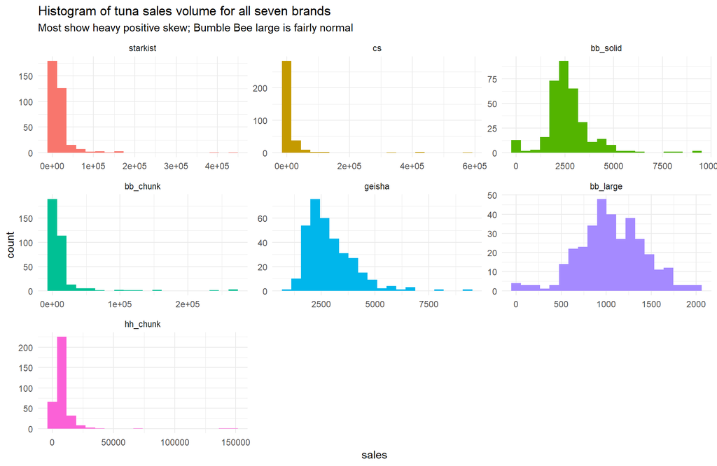

```r
tuna_sales <- tuna_brands %>%
  select(week, move_starkist, move_cs, move_bb_solid, move_bb_chunk,
         move_geisha, move_bb_large, move_hh_chunk) %>%
  gather(key = "brand", value = "sales", - week) %>%
  mutate(brand = rep(brand_names, each = nrow(tuna)),
         brand = factor(brand, levels = brand_names))

tuna_sales %>%
  ggplot(aes(sales, fill = brand)) +
  geom_histogram(bins = 20, show.legend = F) +
  facet_wrap(facets = "brand", scales = "free") +
  labs(title = "Histogram of tuna sales volume for all seven brands",
       subtitle = "Most show heavy positive skew; Bumble Bee large is fairly normal")
```

With the skewed volume distributions, I wanted to check on each brand’s median weekly sales volume. These were visible on the histograms but, to get exact values, the table helps illustrate the top sales brands. As seen, Starkist has the largest median sales volume by a fair margin. Here, it almost looks like there are closer to four volume tiers even though broadly there seems to be high and low volume groups.

```r
volume_table <- tuna_sales %>%
  group_by(brand) %>%
  summarise(median_volume = median(sales)) %>%
  mutate(median_volume = round(median_volume, 2)) %>%
  arrange(desc(median_volume))

volume_table %>%
  custom_kable()
```

| brand | median_volume |
| --- | --- |
| starkist | 10801.0 |
| cs | 6633.0 |
| hh_chunk | 6315.0 |
| bb_chunk | 6215.5 |
| geisha | 2617.5 |
| bb_solid | 2537.5 |
| bb_large | 1044.5 |

Given the data is comprised of weekly entries for each brand, I wanted to review the sales volumes as a time series. While the set does not include any specific dates, it still has each week number, so I’ve visualized volumes at each record. As an additional transformation, I’ve also taken the log volume so the larger sales spikes evident in the histogram are dampened.

Interestingly, the series seems to add further evidence that Starkist, Chicken of the Sea, Bumble Bee Chunk, and HH Chunk are similar. They each have congruent time series shape, although HH chunk shows some differences. The same series pattern is evident for both Bumble Bee solid large too while Geisha seems more unique.

Overall, it also appears that Bumble Bee large and solid are the only brands to see an increasing volume trend; the other brands seem stagnant or even declining. Conversely, these trends are minor in both directions so it seems volumes are neutral overall, despite periodic fluctuations. My intuition here is that the volume is seasonally affected, which is highlighted by the variable sales volumes. Unfortunately without dates, it’s hard to determine which season are associated with the sales variability but, this affect is still observable.

Another interesting feature here are the volume spikes for each brand. Of note, I think week 76 helps further illustrate some of the competitive volume dynamics well. During this week, Starkist, Chicken of the Sea, Bumble Bee Chunk, and to a lesser extent HH Chunk all display large sales spikes. Concurrently, Bumble Bee solid and Bumble Bee large volumes substantially drop. Geisha sales seem slightly elevated, though not in any exaggerated fashion.

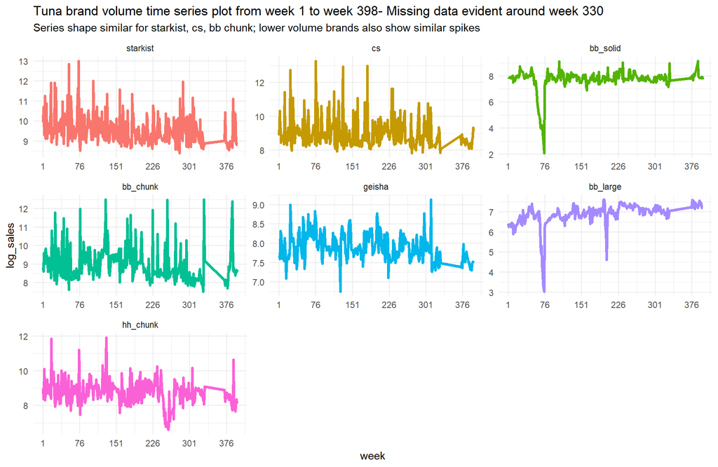

```r
tuna_sales %>%
  mutate(log_sales = log(sales)) %>%
  ggplot(aes(week, log_sales, colour = brand)) +
  geom_line(size = 1.3, show.legend = F) +
  facet_wrap(facets = "brand", scales = "free") +
  scale_x_continuous(breaks = seq(1, 400, 75)) +
  labs(title = "Tuna brand volume time series plot from week 1 to week 398- Missing data evident around week 330",
       subtitle = "Series shape similar for starkist, cs, bb chunk; lower volume brands also show similar spikes")
```

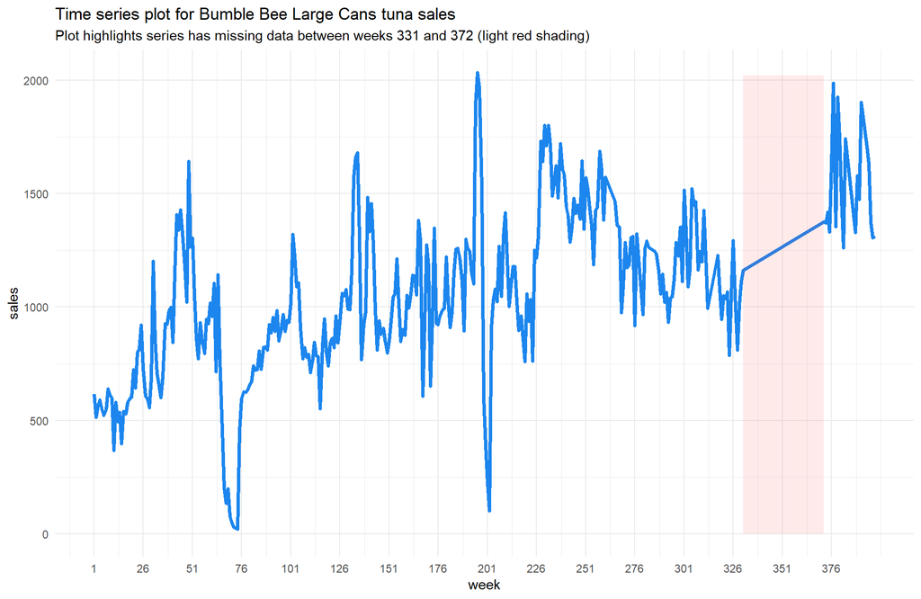

```r
tuna_sales %>%
  filter(brand == "bb_large") %>%
  ggplot(aes(week, sales)) +
  geom_line(size = 1.3, colour = "dodgerblue2") +
  annotate(geom = "rect", xmin = 331, xmax = 372,
           ymin = 0, ymax = 2020,
           alpha = .1, fill = "firebrick1") +
  scale_x_continuous(breaks = seq(1, 400, 25)) +
  labs(title = "Time series plot for Bumble Bee Large Cans tuna sales",
       subtitle = "Plot highlights series has missing data between weeks 331 and 372 (light red shading)")
```

Before moving onto the price variables, I also wanted to evaluate how much share of the total weekly sales each brand experienced. To do this, I’ve divided each brand’s sales volume per week by the total category sales. In the table below, Starkist had a median share of about 25% each week followed by Chicken of the Sea and HH Chunk. Of note, the market share median drops by almost 8% from Bumble Bee Chunk to Geisha demarcating the high and low volume brands.

```r
tuna_shares <- tuna_brands %>%
  mutate(log_sales = log(total_sales)) %>%
  mutate_at(vars(2:8), function(x) x / tuna_brands$total_sales) %>%
  select(1:8) %>%
  gather(key = "brand", value = "share", -week) %>%
  mutate(brand = rep(brand_names, each = nrow(tuna)),
         brand = factor(brand, levels = brand_names))

share_table <- tuna_shares %>%
  group_by(brand) %>%
  summarise(brand_share_median = median(share)) %>%
  mutate(brand_share_median = round(brand_share_median, 4) * 100) %>%
  arrange(desc(brand_share_median))

share_table %>%
  custom_kable()
```

| brand | brand_share_median |
| --- | --- |
| starkist | 25.40 |
| cs | 14.54 |
| hh_chunk | 14.05 |
| bb_chunk | 13.76 |
| geisha | 5.38 |
| bb_solid | 5.06 |
| bb_large | 2.10 |

Viewing these weekly shares from a time series perspective shows a variable category. The top share brand by average, Starkist, shows weeks with almost full market share followed shortly after by weeks with almost zero market share. There appears to be some seasonal component here but, the series resembles white noise and as such, probably has a strong stochastic component.

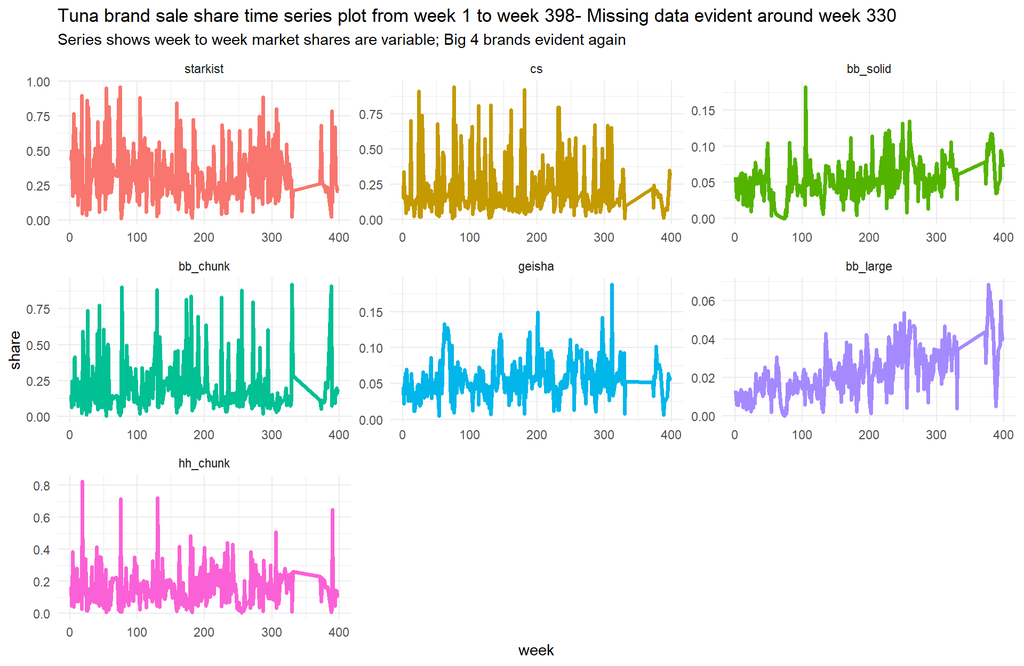

```r
tuna_shares %>%
  ggplot(aes(week, share, colour = brand)) +
  geom_line(size = 1.3, show.legend = F) +
  facet_wrap(facets = "brand", scales = "free") +
  labs(title = "Tuna brand sale share time series plot from week 1 to week 398- Missing data evident around week 330",
       subtitle = "Series shows week to week market shares are variable; Big 4 brands evident again")
```

Having reviewed volume, I’ll switch focus here to price. To do so, I’m starting off with a quantile table for each brand’s pricing. Immediately, it seems clear that there are three distinct price groups. Starkist, Chicken of the Sea, Bumble Bee Chunk, and HH chunk have very congruent price quantiles. Most have a price range of about 60 cents, although HH chunk is more narrow at around 36 cents. Combining this with the previous volume analysis, it’s clear that these are low cost, high volume brands.

The higher cost tuna brands here are Bumble Bee Solid, Geisha, and Bumble Bee large, although it is unique given how much higher the line’s prices are. These more expensive brands have narrower price quantiles with Geisha and Bumble Bee solid at around .36 from the highest to low price. Bumble Bee large is in line with the less expensive brands with about a 60 cent price spread. The competitive landscape is clearer following the initial price quantile review as it appears there are low cost, high volume brands and more expensive, low volume brands.

As a methodological note, I’ve also expoentiated the initial log prices here so they are more interpretable during the exploratory work. The final elasticity models will rely on both log volume and sales but, for now I find it more intuitive to work with the actual price levels.

```r
tuna_brands %>%
  select(10:16) %>%
  apply(., 2, quantile) %>%
  as.data.frame() %>%
  mutate_all(function(x) exp(x)) %>%
  rownames_to_column(var = "quantile") %>%
  custom_kable()
```

| quantile | lprice_starkist | lprice_cs | lprice_bb_solid | lprice_bb_chunk | lprice_geisha | lprice_bb_large | lprice_hh_chunk |
| --- | --- | --- | --- | --- | --- | --- | --- |
| 1 | 0.4349303 | 0.2900000 | 1.499831 | 0.3900791 | 1.221796 | 2.990000 | 0.4900000 |
| 2 | 0.7417565 | 0.7462904 | 1.672490 | 0.7145285 | 1.419828 | 3.365818 | 0.7069464 |
| 3 | 0.8177306 | 0.8170906 | 1.766384 | 0.8240153 | 1.481517 | 3.395723 | 0.7458779 |
| 4 | 0.8872048 | 0.8806084 | 1.776202 | 0.8886752 | 1.509326 | 3.414710 | 0.8077557 |
| 5 | 0.9715048 | 0.9156761 | 1.845615 | 0.9924570 | 1.579051 | 3.516870 | 0.8594338 |

Visualizing all the brand prices, it’s clear that the distributions are all negatively skewed. This makes sense given the brands likely offer special discounts and promotions while trying to maintain profitability but, do not unnecessarily raise prices barring some wider business change.

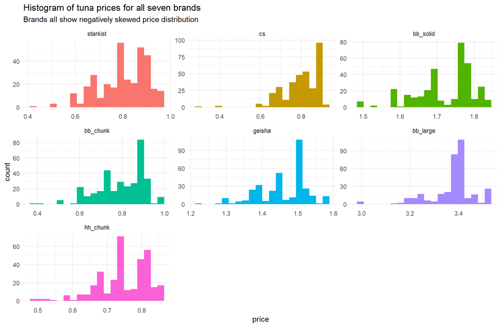

```r
tuna_prices <- tuna_brands %>%
  select(week, lprice_starkist, lprice_cs,
         lprice_bb_solid, lprice_bb_chunk, lprice_geisha,
         lprice_bb_large, lprice_hh_chunk) %>%
  gather(key = "brand", value = "price", - week) %>%
  mutate(price = exp(price),
         brand = rep(brand_names, each = nrow(tuna)),
         brand = factor(brand, levels = brand_names))

tuna_prices %>%
  ggplot(aes(price, fill = brand)) +
  geom_histogram(bins = 20, show.legend = F) +
  facet_wrap(facets = "brand", scales = "free") +
  labs(title = "Histogram of tuna prices for all seven brands",
       subtitle = "Brands all show negatively skewed price distribution")
```

The median price table again reaffirms that there are broadly three cost groups. Bumble Bee large is really an outlier and the most unique brand offering given it has a median price of $3.40. The other brands are largely split on median price above and below one dollar.

```r
price_table <- tuna_prices %>%
  group_by(brand) %>%
  summarise(median_price = median(price)) %>%
  mutate(median_price = round(median_price, 2)) %>%
  arrange(desc(median_price))

price_table %>%
  custom_kable()
```

| brand | median_price |
| --- | --- |
| bb_large | 3.40 |
| bb_solid | 1.77 |
| geisha | 1.48 |
| starkist | 0.82 |
| cs | 0.82 |
| bb_chunk | 0.82 |
| hh_chunk | 0.75 |

The price time series shows the movement over 338 weeks. I made a comment earlier about not seeing any major price increases which is confirmed here. Starkist, HH chunk, and Bumble Bee chunk show modest price increases but otherwise, the brands mostly lower prices. The series shape, when coupled with the volume insights, leads me to believe the general production and operating costs for these brands are generally stable because the firms have not increased prices while sales have remained constant.

Extrapolating further, my guess is this means that the space is a high profit margin category because inflation increases over 6.5 years should inherently affect costs somewhere but, these do not show up in price increases. However, this might also reflect a highly price sensitive consumer group that is not willing to pay higher prices for the good. Taken together, this sets up that these fluctuating discounts are tactical marketing opportunities firms are using to increase volume, which if the profit margin assumption is correct, is still a very profitable exercise.

Of course, this is only for one store chain so there are likely missing insights to enhance the analysis. While the exact explanation is not clear, and likely cannot decisively be pinned down here, these ideas help frame the competitive analysis given producers are bound but these possible market dynamics.

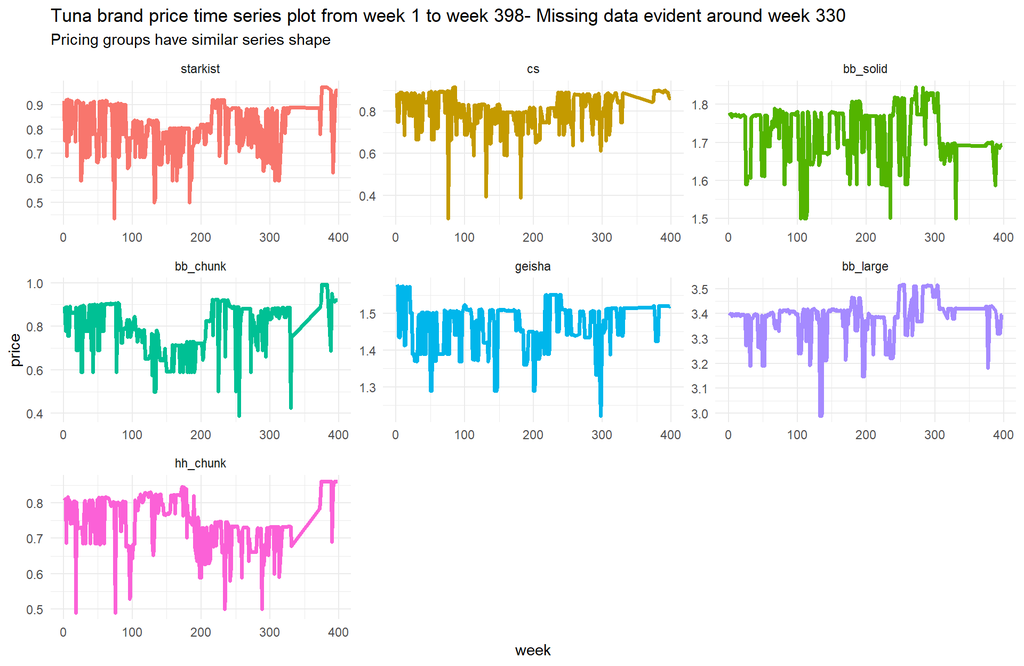

```r
tuna_prices %>%
  ggplot(aes(week, price, colour = brand)) +
  geom_line(size = 1.3, show.legend = F) +
  facet_wrap(facets = "brand", scales = "free") +
  labs(title = "Tuna brand price time series plot from week 1 to week 398- Missing data evident around week 330",
       subtitle = "Pricing groups have similar series shape")
```

With univariate review for volume, share, and price, I’ll work towards a more multivariate analysis. Starting this, I’ve developed and visualized a correlation matrix for the sales volume. The last row is particularly interesting given it represents each brand’s volume correlation to the overall total. Here, it’s clear that Chicken of the Sea volume is the only brand with a strong positive correlation with total sales. Additionally, BB large shows a negative correlation with total sales.

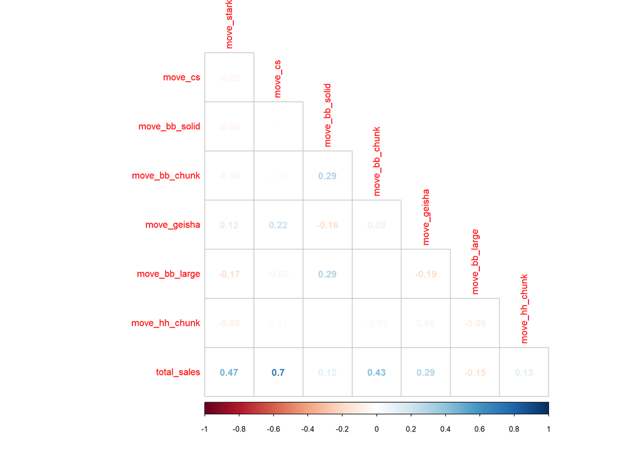

```r
tuna_brands %>%
  select(2:9) %>%
  cor() %>%
  corrplot(method = "number", type = "lower", diag = F)
```

The large Chicken of Sea correlation stood out so I wanted to review the bivariate relationship more closely. As seen, the large coefficient is driven largely by four volume outliers. These volume spikes were evident during the univariate portion. To get a sense for how these few points affect the relationship, I filtered any records with a z-score of less than four. It’s clear that they do exaggerate the correlation.

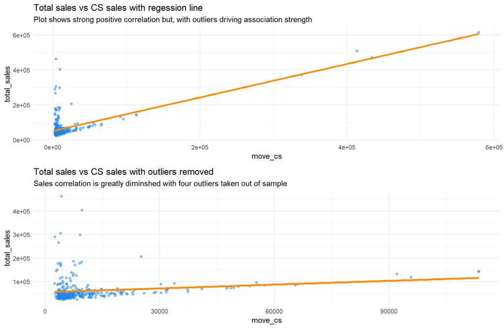

```r
cs_sales <- tuna_brands %>%
  ggplot(aes(move_cs, total_sales)) +
  geom_jitter(colour = "dodgerblue2", alpha = .5) +
  geom_smooth(method = "lm", se = F, colour = "darkorange", size = 1.3) +
  labs(title = "Total sales vs CS sales with regession line",
       subtitle = "Plot shows strong positive correlation but, with outliers driving association strength")

cs_sales_update <- tuna_brands %>%
  mutate(cs_zscore = scale(x = move_cs) %>% as.numeric()) %>%
  filter(cs_zscore < 4) %>%
  ggplot(aes(move_cs, total_sales)) +
  geom_jitter(colour = "dodgerblue2", alpha = .5) +
  geom_smooth(method = "lm", se = F, colour = "darkorange", size = 1.3) +
  labs(title = "Total sales vs CS sales with outliers removed",
       subtitle = "Sales correlation is greatly diminshed with four outliers taken out of sample")

grid.arrange(cs_sales, cs_sales_update)
```

That said, it led me to think about which brands might see high correlations when there is a category sales spike. It appears that during the largest sales increases, Chicken of the Sea accounts for much of the volume. This may indicate that the brand tries to position the brand as a first mover and in turn, sees the largest sales boost.

To evaluate this, I’ve included price as a third variable. As seen, the brand has the lowest prices during these volume increases. This adds some nuance to the high and low volume brand split. The plot seems to indicate that Chicken of the Sea, even amongst high volume brands, might be a brand setting the market, which other brands react too.

Again,it’s still unclear if this is a certain day or event that causes the spike but, it seems that during these periods, Chicken of the Sea seems to lead the category volume. Additionally, this has not been formally modelled but, as an early insight, there does seem to be some brand differentiation here.

As a final point, the plot also confirms that there is a negative, albeit slight, correlation between total sales and Bumble Bee large sales. The coefficient size is likely too small to read much into but, it might signal they attract transient consumers from the low cost brands during weeks when there isn’t any major pricing promotion.

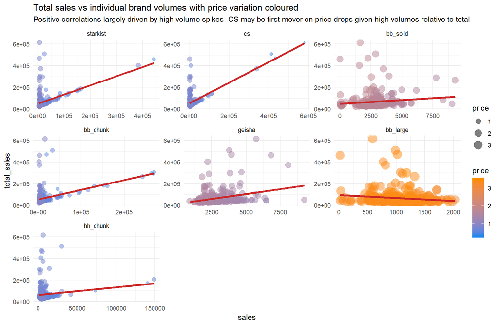

```r
tuna_brands %>%
  select(2:9) %>%
  gather(key = "brand", value = "sales", -total_sales) %>%
  mutate(brand = rep(brand_names, each = nrow(tuna)),
         brand = factor(brand, levels = brand_names)) %>%
  cbind(tuna_prices$price) %>%
  rename(price = "tuna_prices$price") %>%
  ggplot(aes(sales, total_sales, colour = price, size = price)) +
  geom_jitter(alpha = .5) +
  geom_smooth(method = "lm", se = F, colour = "firebrick3", size = 1.3) +
  facet_wrap(facets = "brand", scales = "free") +
  scale_colour_gradient(low = "dodgerblue2", high = "darkorange") +
  labs(title = "Total sales vs individual brand volumes with price variation coloured",
       subtitle = "Positive correlations largely driven by high volume spikes- CS may be first mover on price drops given high volumes relative to total")
```

Below, I’ve constructed another correlation matrix with log total sales and each logged price. The variables represented in the matrix will form the multivariate sales regression model, so it’s positive to see limited multicollinearity. That said, there isn’t any strong negative correlations, so some of the coefficients might not be significant. From a theory standpoint though, seeing all the prices have negative correlations with log sales shows the expected elasticity relationship where as price increases, sales go down.

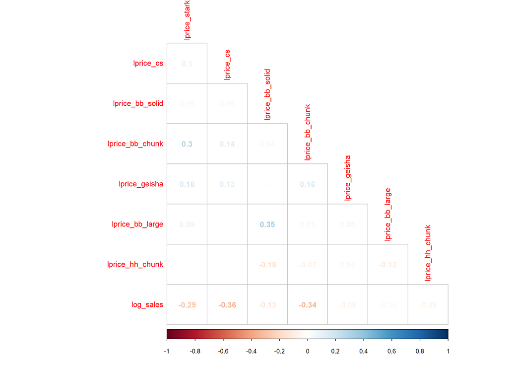

```r
tuna_brands %>%
  select(-week) %>%
  select(total_sales, lprice_starkist,
         lprice_cs, lprice_bb_solid, lprice_bb_chunk, lprice_geisha,
         lprice_bb_large, lprice_hh_chunk) %>%
  mutate(log_sales = log(total_sales)) %>%
  select(-total_sales) %>%
  cor() %>%
  corrplot(method = "number", type = "lower", diag = F)
```

I wanted to see how each sales and price relationship looked so I’ve constructed a faceted plot with all the brands. Five of the brands shows strong negative relationships but, both Bumble Bee large and solid seem less noteworthy. These two brands still likely have a significant price and sales association but, they do not seem as elastic.

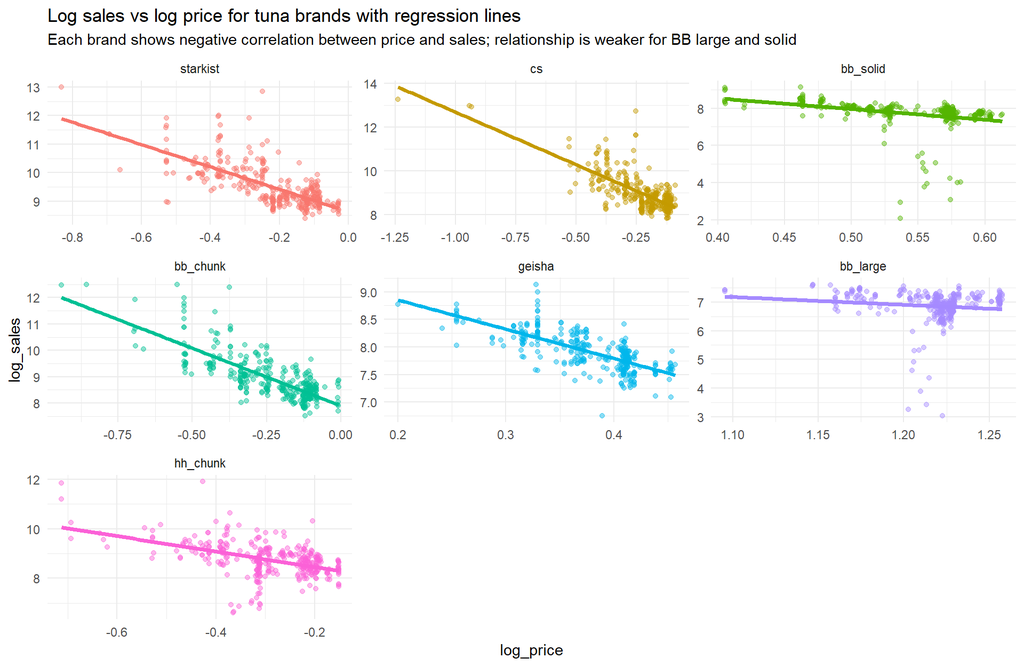

```r
tuna_prices %>%
  left_join(x = ., y = tuna_sales, by = c("week", "brand")) %>%
  mutate(log_price = log(price),
         log_sales = log(sales)) %>%
  ggplot(aes(log_price, log_sales, colour = brand)) +
  geom_jitter(alpha = .45, show.legend = F) +
  geom_smooth(method = "lm", se = F, size = 1.3, show.legend = F) +
  facet_wrap(facets = "brand", scales = "free") +
  labs(title = "Log sales vs log price for tuna brands with regression lines",
       subtitle = "Each brand shows negative correlation between price and sales; relationship is weaker for BB large and solid")
```

As the final EDA component, I wanted to look at the price and sales time series simultaneously. However, the scales for both series are different and do not line up well, even when both are log transformed. To avoid this, I’ve developed a faceted grid plot so both have independent scales.